# Bible prophecies

Dougals Wu

2015-05-29

In **Mark 13**, Jesus told 10 prophecies. I am going to use bayesian inference to

- test the hypothesis that prophecies in bible are fulfilled by chance
  - H<sub>0</sub>: p = 0.5
- predict the chance of these 10 prophecies to be fulfilled.

It is said that ~2500 prophecies were made in the bible and 2000 of them have been fulfilled ([ref](http://www.reasons.org/articles/articles/fulfilled-prophecy-evidence-for-the-reliability-of-the-bible)). Assuming prophecies are binomial trials (true or false only), in a bayesian approach, the equation for posterior distribution is:

$$P(p | data) = \frac{p^{N_{\text{success}}}(1-P)^{N_{\text{failure}}}}{\int_{0}^{1}p^{N_{\text{success}}}(1-P)^{N_{\text{failure}}}\text{ }dp}$$

Assume those prophecies that are not fulfilled at this point as failure. So we have:

- N<sub>success</sub> = 2000 and
- N<sub>failure</sub> = 490. (removed the 10 prophecies in **Mark 13**)

As this denominator are not easily integrated in *R*, I was suggested to use the following algorithm using *pdf of a beta distribution* to get the probability of prophecies-fulfilled-probability ([ref](http://www.sta.cuhk.edu.hk/KHWu/default.aspx)).

$$f(x) = \frac{x^{\alpha-1}(1-x)^{1-\beta}}{B(\alpha,\beta)} = \frac{\Gamma(\alpha+\beta)}{\Gamma(\alpha)\Gamma(\beta)}x^{\alpha}(1-x)^{1-\beta}$$
where $\Gamma(y)=(y-1)!$.
$$\int_0^1 f(x)dx =1$$
$$\int_0^1 \frac{\Gamma(\alpha+\beta)}{\Gamma(\alpha)\Gamma(\beta)}x^{\alpha}(1-x)^{1-\beta} dx =1$$
$$\int_0^1 x^{\alpha}(1-x)^{1-\beta} = \frac{\Gamma(\alpha)\Gamma(\beta)}{\Gamma(\alpha+\beta)}$$
$$\int_0^1 x^{\alpha}(1-x)^{1-\beta} = \frac{(\alpha-1)! (\beta-1)!}{(\alpha+\beta-1)!}$$
$$ln[\int_0^1 x^{\alpha}(1-x)^{1-\beta}] = ln[\frac{(\alpha-1)! (\beta-1)!}{(\alpha+\beta-1)!}]= \sum_{i=1}^{\alpha-1} ln i + \sum_{i=1}^{\alpha-1} ln i- \sum_{i=1}^{\alpha+\beta-1} ln i$$

- iterating from 0 to 1 for generating the pdf curves for posterior distribution. Let prior be 1,
- iterating from 2000 (current fulfilled prophecies) to 2490 (all prophecies except the ones in **Mark 13**)

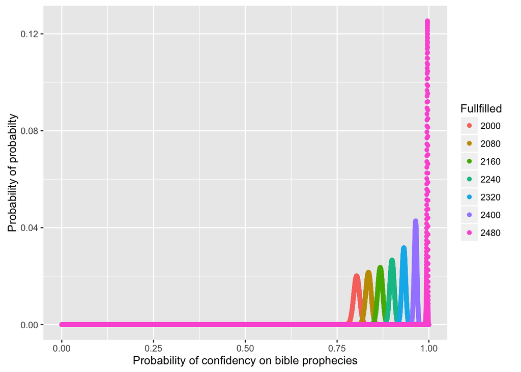

```r
library(Rcpp)
library(ggplot2)
library(tibble)
library(dplyr)
library(purrr)

sourceCpp('/Users/wckdouglas/scripts/softwares/R/Rcpp/integral.cpp')
all <- 2490
success <- 2000
prob <- seq(0,1,0.00005)

make_df <- function (x) {
    d <- data_frame(probofProb=probOfProb(prob,x,all-x),
            success = x,
            prob = prob)
    return(d)
}
result = seq(success,all,80) %>%
    map(make_df) %>%
    reduce(rbind)

ggplot(data= result,aes(x=prob,y=probofProb,color=as.factor(success))) +
    labs(y = 'Probability of probabilty',
         x = 'Probability of confidency on bible prophecies',
         color='Fullfilled') +
    geom_point()
```

From the red curve (N<sub>success</sub>=2000), getting the likelihood ratio between 0.8 and 0.5 (random).

```r
likelihood_ratio = probOfProb(0.8,2000,500)/probOfProb(0.5,2000,500)
likelihood_ratio
```

```
## [1] 1.86192e+209
```

In addition, this test assumes bible prophecies are bernoulli trials where the result can only be 1 or 0. A detailed accuracy test has been done in [here](http://www.bereanpublishers.com/the-odds-of-eight-messianic-prophecies-coming-true/).

And it is **very** likely that ~80% of chance that the prophecies in **Mark 13** will be fulfilled!